# Milestone Report

Tianxiao Shi

12/23/2019

## Introduction

This report is for my Coursera Data Science Specialization Capstone project. The objective of this report is on the Exploratory Data Analysis which will lead to the final development of products. I will study on three data sets and design an R shiny app to predict user’s next input words. The data source is from news, blogs, and tweets. I will look at the datasets from each of the sources and do a clean up of the data.

## Exploratory Data Analysis

### File Summary

First I will read all the three files and do a summary on the Word counts, line counts and basic data tables.

```r
library(stringr)
library(knitr)
usblogs_file = 'final/en_US/en_US.blogs.txt'
usnews_file = 'final/en_US/en_US.news.txt'
ustwitter_file = 'final/en_US/en_US.twitter.txt'
usblogs = readLines(usblogs_file)
usnews = readLines(usnews_file)
ustwitter = readLines(ustwitter_file)
files = c(usblogs_file,usnews_file,ustwitter_file)
mbsizes = sapply(files, function(x) {file.size(x)/1024^2})
stats = sapply(list(usblogs,usnews,ustwitter),function(x){ c(length(x) , sum(str_count(x,'\\S+')) )})
invisible(gc())
stats = rbind(mbsizes,stats)
stats = as.data.frame(stats)
names(stats) = c('usblogs','usnews','ustwitter')
row.names(stats) = c('filesize(MB)','lines','word_count')
kable(stats,digits = 0)
```

|  | usblogs | usnews | ustwitter |
| --- | --- | --- | --- |
| filesize(MB) | 200 | 196 | 159 |
| lines | 899288 | 77259 | 2360148 |
| word_count | 37334441 | 2643972 | 30373792 |

### Build Corpus

Next, I will build the corpus and do a clean up of the data. Since the raw texts are very large, I will just take a sample from each texts.

```r
usblogs = usblogs[seq(1,length(usblogs),1000)]
usnews = usnews[seq(1,length(usnews),1000)]
ustwitter = ustwitter[seq(1,length(ustwitter),1000)]
invisible(gc())   #to clean up memory of garbage
raw_text = c(usblogs,usnews,ustwitter)
invisible(gc())

# build corpus
library(tm)
raw_source = VectorSource(raw_text)
invisible(gc())
raw_corpus <- VCorpus(raw_source)
invisible(gc())

# clean the corpus
clean_corpus <- function(corpus){
  corpus <- tm_map(corpus, content_transformer(tolower)) # convert to lower case
  corpus <- tm_map(corpus, stripWhitespace) # remove white space
  corpus <- tm_map(corpus, removePunctuation) # remove punctuation
  corpus <- tm_map(corpus,content_transformer(function(x) gsub("[[:digit:]]","",x)))# remove numbers
  corpus <- tm_map(corpus,content_transformer(function(x) gsub(" th", "",x))) # remove th (like 4th)
  corpus <- tm_map(corpus,content_transformer(function(x) gsub("http[[:alnum:]]*","",x))) # remove url
  corpus <- tm_map(corpus,content_transformer(function(x) iconv(x, "latin1", "ASCII", sub=""))) # remove non-ASCII characters
  corpus <- tm_map(corpus,content_transformer(function(x) gsub("([[:alpha:]])\\1{2,}", "\\1\\1", x))) # remove repeated alphabets in a word
  gc()
  return(corpus)
}

corpus <- clean_corpus(raw_corpus)

save(corpus,file='corpus.RData')
```

### Build N-Gram model

Next I will build N-Gram models, which is uni-gram, bi-gram and tri-gram. I will also plot the top 10 word frequencies.

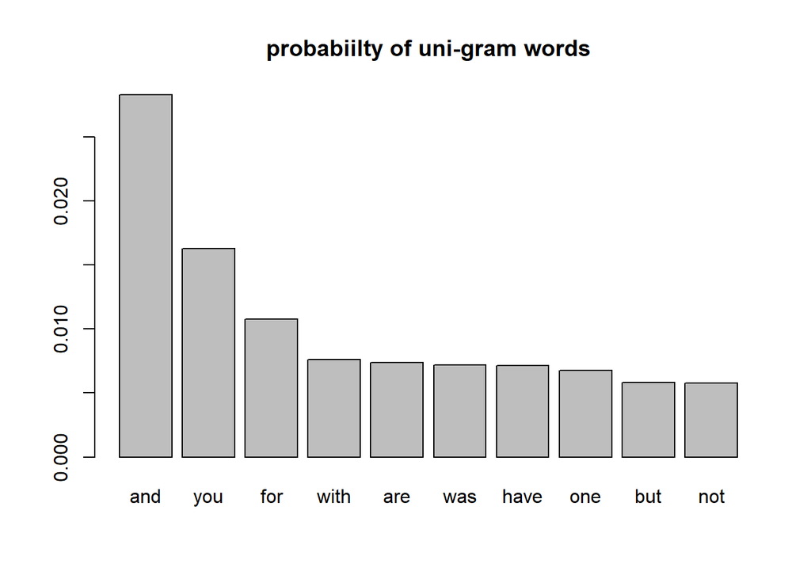

```r
load('corpus.RData')
# unigram
library(tm)
library(RWeka)
unigram <- function(x) NGramTokenizer(x, Weka_control(min = 1, max = 1))
tdm1<-TermDocumentMatrix(corpus,control = list(tokenize = unigram))
invisible(gc())
wordMatrix1 = as.data.frame((as.matrix(  tdm1 )) )
invisible(gc())
v1 <- sort(rowSums(wordMatrix1),decreasing=TRUE)
d1 <- data.frame(word = names(v1),freq=v1)
rm(tdm1,wordMatrix1)
for(i in 1:10) gc()
# word probablity
d1$prob = d1$freq/sum(d1$freq)
barplot(d1[1:10,c('prob')],names.arg = d1[1:10,'word'],main = 'probabiilty of uni-gram words')
```

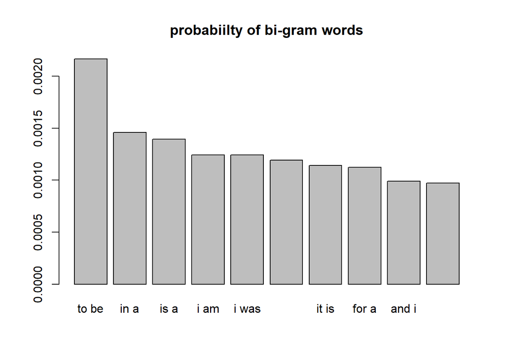

```r
#bi-gram
bigram <- function(x) NGramTokenizer(x, Weka_control(min = 2, max = 2))
tdm2<-TermDocumentMatrix(corpus,control = list(tokenize = bigram))
invisible(gc())
wordMatrix2 = as.matrix(  tdm2 )
wordMatrix2 = as.data.frame(wordMatrix2 )
invisible(gc())
v2 <- sort(rowSums(wordMatrix2),decreasing=TRUE)
d2 <- data.frame(word = names(v2),freq=v2)
rm(tdm2,wordMatrix2)
for(i in 1:10) gc()
# word probablity
d2$prob = d2$freq/sum(d2$freq)
barplot(d2[1:10,c('prob')],names.arg = d2[1:10,'word'],main = 'probabiilty of bi-gram words')
```

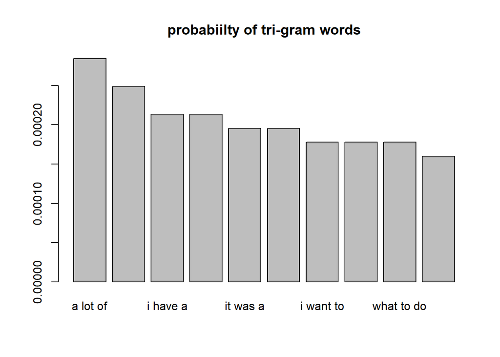

```r
#tri-gram
trigram <- function(x) NGramTokenizer(x, Weka_control(min = 3, max = 3))
tdm3<-TermDocumentMatrix(corpus,control = list(tokenize = trigram))
invisible(gc())
wordMatrix3 = as.matrix(  tdm3 )
wordMatrix3 = as.data.frame(wordMatrix3 )
invisible(gc())
v3 <- sort(rowSums(wordMatrix3),decreasing=TRUE)
d3 <- data.frame(word = names(v3),freq=v3)
rm(tdm3,wordMatrix3)
for(i in 1:10) gc()
# word probablity
d3$prob = d3$freq/sum(d3$freq)
barplot(d3[1:10,c('prob')],names.arg = d3[1:10,'word'],main = 'probabiilty of tri-gram words')
```

## Next Step Plan

In the later section, we will build a predictive model using the tokens, and develop shiny app for user to input word and phrases, and predict on the next word.